# ENGR 3703 Project - Ben Drumm

As you go through the project think of an application... a good application is the suspension (springs and shocks or struts) in a car. As the car goes along a bumpy road the suspension responds to bumps (i.e. $F(t)$) by bouncing on springs (with constant $k$) and being damped from too much bouncing by a damper (i.e. shock absorbers) with damping constant $c$.

## Background - Unforced Systems ($F(t)=0$)

$\large m \frac{d^2x}{dt^2} + c \frac{dx}{dt} + k x = F(t)$

Introducting a *dot* notation for the time derivatives and dividing through by $m$ gives:

$\large \ddot x + \frac{c}{m} \dot x + \frac{k}{m} x = \frac{F(t)}{m}$

One thing of interest is to solve for $x(t)$ the *homgenous* case... that is when $F(t)=0$. The easiest way to do this is to propose that the solution is of the form: $x(t)=C e^{\lambda t}$ where $C$ and $\lambda$ are unknown.

With this proposed solution $\ddot x = C \lambda^2 e^{\lambda t}$, and $\dot x = C \lambda e^{\lambda t}$. Substituting gives

$\large C \lambda^2 e^{\lambda t} + \frac{Cc}{m} \lambda e^{\lambda t} + \frac{Ck}{m} e^{\lambda t} = 0 ~~~\rightarrow~~~ (\lambda^2 + \frac{c}{m} \lambda + \frac{k}{m})C e^{\lambda t} = 0$

Since $C e^{\lambda t} = 0$ would be a trivial solution, we conclude that:

$\large \lambda^2 + \frac{c}{m} \lambda + \frac{k}{m} = 0$

Before proceeding it's good to introduce a quantity that is really important for oscillating/vibrating systems, the natural frequency, $\omega_n$. This is the angular frequency that an undamped system will tend to vibrate at (see other refs for examples of this):

$\large \omega_n = \sqrt{\frac{k}{m}}$

From the quadratic formula:

$\large \lambda = \frac{-\frac{c}{m} \pm \sqrt{(\frac{c}{m})^2 - 4 {\omega}_n^2}}{2} = -\frac{c}{2m} \pm \sqrt{(\frac{c}{2m})^2 - {\omega}_n^2} $

So let's define the ratio of the actual damping constant, c, to the critical damping constant to be be the dimensionless damping coefficient,

$\large \zeta = \frac{c}{c_c}=\frac{c}{2m \omega_n}$ So that:

$\large \lambda = -\frac{c}{2m}\frac{\omega_n}{\omega_n} \pm \sqrt{(\frac{c}{2m})^2 (\frac{\omega_n}{\omega_n})^2 - {\omega}_n^2} = -\frac{c}{2m \omega_n}\omega_n \pm \sqrt{(\frac{c}{2m\omega_n})^2 {\omega}_n^2 - {\omega}_n^2} $

Finally,

$\large \lambda = -\zeta\omega_n \pm \omega_n \sqrt{\zeta^2 - 1} $

Note that $\zeta$ and $\omega_n$ are based on positive constants, $c$, $k$, and $m$ and so we can assume they will also be positive.

# Runge Kutta Methods to Solve ODEs

Runge-Kutta (RK) is very widely used to solve ODE problems. In this project we will be using Runge-Kutta to find a very accurate way of finding the slope and solving two ODE's and then making graphs of x vs. t and v vs. time. It's really an extension of Euler, Heun, and midpoint methods. By choosing different and additional intermediate points between $x_i$ and $x_{i+1}$ the truncation error can be reduced even further.

# What we are doing

In the background notebook, we determined that:

$\large \ddot x + 2 \zeta \omega_n \dot x + {\omega}_n^2 x = \frac{F(t)}{m}$

## Project Prep

#### Step 1 - Rewrite as two ODEs:

*Equation 1:* $f_x=\frac{dx}{dt} = v$

*Equation 2:* $f_v=\frac{dv}{dt} = -2 \gamma v + -k x$

#### Step 2 - Solution Planning:

1. Find $x_{i+1}$ using Equation 1: $x_{i+1} = x_i + Slope(t_i,x_i,v_i) h$
2. Find $v_{i+1}$ using Equation 2: $v_{i+1} = v_i + Slope(t_i,x_i,v_i) h$

# Below is the code for an over damped situation

#### Overdamped Systems: $c > c_c$

In this case the system does not move well and does not osciallate well either. If this were a diagram of the suspension in a car, then the shocks would be extremely stiff and not absorb much of the bumpiness on the road at all.

In this case there would be two real roots: $\lambda_I$ and $\lambda_{II}$:

$\large \lambda_{I,II} = -\zeta\omega_n \pm \omega_n \sqrt{\zeta^2 - 1} $

But what do these roots look like... consider:

$\large \lambda_{I,II} = \omega_n(-\zeta \pm \sqrt{\zeta^2 - 1}) $

Since $\omega_n$ and $\zeta$ are both positive, if you were to take the $-$ of the $\pm$ (leading to finding $\lambda_{II}$), then you would clearly get a $\lambda_{II}$ that is negative:

$\large \lambda_{II} = -\omega_n(\zeta + \sqrt{\zeta^2 - 1}) $

For the case of $+$ of the $\pm$ and considering that $\zeta > \sqrt{\zeta^2 - 1}$:

$\large \lambda_{I} = -\omega_n(\zeta - \sqrt{\zeta^2 - 1}) $

*It will be the case that both $\lambda_I$ and $\lambda_{II}$ are negative*. So both solutions represent exponential decay:

$C_I e^{\lambda_I t}$ and $C_{II} e^{\lambda_{II} t}$

Recall for linear ODEs the sum of solutions is also a solution... so we end up with:

$\large x_{\small overdamped}(t) = C_I e^{\lambda_I t} + C_{II} e^{\lambda_{II} t}$

#### Overdamped Example

Let $x(0) = 0$ and $v(0)=1$ m/s. So that:

$x(0) = C_I + C_{II} = 0$ so $C_{II} = -C_I$

and:

$v(0) = C_I \lambda_I + C_{II} \lambda_{II} = C_I(\lambda_I -\lambda_{II}) = 1 \rightarrow C_I = \frac{1}{\lambda_I -\lambda_{II}}$ and $C_{II} = \frac{1}{\lambda_{II} -\lambda_I} $

$\large x(t) = \frac{1}{\lambda_I -\lambda_{II}} e^{\lambda_I t} + \frac{1}{\lambda_{II} -\lambda_I}e^{\lambda_{II} t} $

#### where x(0) = 1 and v(0) = 0

#### $\large \zeta {}$ = 10

#### $\large {\omega}{}$ = 1 rad/s

##### In this example F(t) equals 0, as you see from this equation earlier,

##### $\large \ddot x + 2 \zeta \omega_n \dot x + {\omega}_n^2 x = \frac{F(t)}{m}$

##### which means that there is no external force acting upon the system.

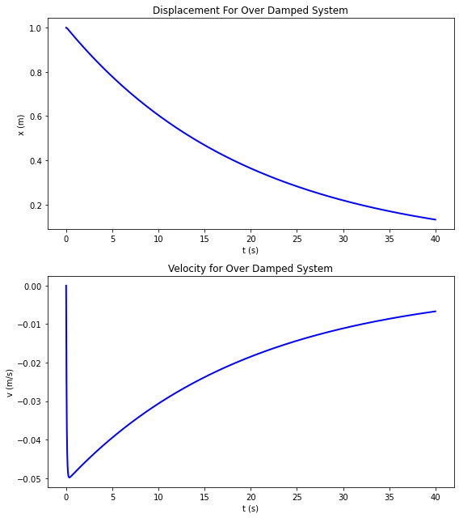

```python
%matplotlib inline
from math import *
import numpy as np
import matplotlib.pyplot as plt

#𝑥¨+2𝜁𝜔𝑛𝑥˙+𝜔2𝑛𝑥=𝐹(𝑡)𝑚
zeta = 10.
omega_n= 1.
#RK4 constants
c1 = 1./6
c2 = 2./6
c3 = 2./6
c4 = 1./6
a2 = 1./2
a3 = 1./2
a4 = 1.
b21 = 1./2
b31 = 0
b32 = 1./2
b41 = 0
b42 = 0
b43 = 0


F_over_m = lambda t: 0     #External force function, here it is 0
f_x = lambda t,x,v: v      #this is equation for dx/dt = v t= indep. x = prim. dep. v = dep
f_v = lambda t,x,v: F_over_m(t)-2*zeta*omega_n*v - (omega_n**2)*x    #this is equation for dv/dt = F_over_m(T)-2*gamma*v- k*x
# t = indep, prim. dep = v x is also dep.

def rk4_x(ti, xi, vi, dt):
    K1 = f_x(ti,xi,vi)
    K2 = f_x(ti+a2*dt,xi+b21*K1*dt,vi)
    K3 = f_x(ti+a3*dt,xi+b31*K1*dt+b32*K2*dt,vi)
    K4 = f_x(ti+a4*dt,xi+b41*K1*dt+b42*K2*dt+b43*K3*dt,vi)
    xip1 = xi+(c1*K1+c2*K2+c3*K3+c4*K4)*dt
    return xip1

def rk4_v(ti, xi, vi, dt):
    K1 = f_v(ti,xi,vi)
    K2 = f_v(ti+a2*dt,xi,vi+b21*K1*dt)
    K3 = f_v(ti+a3*dt,xi,vi+b31*K1*dt+b32*K2*dt)
    K4 = f_x(ti+a4*dt,xi,vi+b41*K1*dt+b42*K2*dt+b43*K3*dt)
    vip1 = vi+(c1*K1+c2*K2+c3*K3+c4*K4)*dt
    return vip1

ti = 0.0    #initial value for t
tf = 40    #final value for t
n = 4000 #number of segments
dt = (tf-ti)/n   #step size
t = np.zeros(n+1)
x = np.zeros(n+1)
v = np.zeros(n+1)
x_iv = 1.0 #m
v_iv = 0.0 #m/s
t[0] = ti      #initial conditions
x[0] = x_iv
v[0] = v_iv

#Loop to send our data through
for i in range(1,n+1):
    t[i] = ti + i*dt
    x[i] = rk4_x(t[i-1],x[i-1],v[i-1],dt)
    v[i] = rk4_v(t[i-1],x[i-1],v[i-1],dt)


fig = plt.figure(figsize=(8,9))
ax1 = plt.subplot(211)
#plt.title("x versus t and v versus t")
plt.plot(t,x,label="x vs. t",color="b",linewidth="2.0")
plt.xlabel("t (s)")
plt.ylabel("x (m)")
plt.title("Displacement For Over Damped System")

ax2 = plt.subplot(212,sharex=ax1)
plt.plot(t,v,label="v vs. t",color="b",linewidth="2.0")
plt.xlabel("t (s)")
plt.ylabel("v (m/s)")
plt.title("Velocity for Over Damped System")

plt.tight_layout()
plt.show()
```

# Below is the code for a under damped situation

#### Underdamped Systems: $c < c_c~~~\zeta<1$

Now we get into complex roots.

$\lambda = -\zeta\omega_n \pm \omega_n \sqrt{\zeta^2 - 1} $

So here, we will get a negative number under the square root.

$\sqrt{-1(1-\zeta^2)} = i \sqrt{1-\zeta^2} $ And we now have

$\lambda = -\zeta\omega_n \pm i \omega_n \sqrt{1-\zeta^2} $

Take note of the quantity $\omega_n \sqrt{1-\zeta^2}$. Also note, since $\zeta$ is less than one, that $ \sqrt{1-\zeta^2}$ will be less than one... so overall this quantity is a kind of a *reduced* frequency. This is due to damping, so this quantity is called the *damped natural frequency*, $\omega_d$ = $\omega_n \sqrt{1-\zeta^2}$ and our new roots are:

$\lambda = -\zeta\omega_n \pm i \omega_d $

$x_{\small underdamp} = C_I e^{(-\zeta\omega_n+i \omega_d)t} + C_{II} e^{(-\zeta\omega_n-i \omega_d)t} = e^{-\zeta\omega_n t} ( C_I e^{i \omega_d t} + C_{II} e^{-i \omega_d t})$

Recalling that $e^{i \theta} = cos{\theta} + i sin{\theta}$ one can rewrite $x(t)$ as:

$x(t) = e^{-\zeta\omega_n t} [ (C_I + C_{II})cos{\omega_d t} + i (C_I - C_{II})sin{\omega_d t} ]$

We will just take the real part of the solution and since $cos{\omega_d t}$ and $sin{\omega_d t}$ can both satisfy the real part of the solution, most sources just write the solution as:

$x_{\small underdamp}(t) = e^{-\zeta\omega_n t} [ D_I cos{\omega_d t} + D_{II} sin{\omega_d t} ]$

It's convenient to also have $v(t)$.

$v(t) = e^{-\zeta\omega_n t} [ -D_I ( \omega_d sin{\omega_d t} + \zeta \omega_n cos{\omega_d t}) + D_{II} (\omega_d cos{\omega_d t} - \zeta \omega_n sin{\omega_d t} ) ]$

#### Underdamped Example

$x(0) = 1 = D_I$

$v(0) = 0 = - \zeta \omega_n + D_{II} \omega_d~~~\rightarrow~~~ D_{II} = \zeta \frac{\omega_n}{\omega_d} $

Finally!

$x(t) = e^{-\zeta\omega_n t} [ cos{\omega_d t} + \zeta \frac{\omega_n}{\omega_d} sin{\omega_d t} ]$

$v(t) = e^{-\zeta\omega_n t} [ -( \omega_d sin{\omega_d t} + \zeta \omega_n cos{\omega_d t}) + \zeta \frac{\omega_n}{\omega_d}(\omega_d cos{\omega_d t} - \zeta \omega_n sin{\omega_d t} ) ]$

#### where x(0) = 1 and v(0) = 0

#### $\large \zeta {}$ = .2

#### $\large {\omega}{}$ = 1 rad/s

##### In this example F(t) equals 0, as you see from this equation earlier,

##### $\large \ddot x + 2 \zeta \omega_n \dot x + {\omega}_n^2 x = \frac{F(t)}{m}$

##### which means that there is no external force acting upon the system.

[figure not shown]

```python
%matplotlib inline
from math import *
import numpy as np
import matplotlib.pyplot as plt

#𝑥¨+2𝜁𝜔𝑛𝑥˙+𝜔2𝑛𝑥=𝐹(𝑡)𝑚
#This zeta is a ratio of C/C(critical), this is value will give us an under damped graph and system
zeta = .2
omega_n= 1
#RK4 constants for classical
c1 = 1./6
c2 = 2./6
c3 = 2./6
c4 = 1./6
a2 = 1./2
a3 = 1./2
a4 = 1.
b21 = 1./2
b31 = 0
b32 = 1./2
b41 = 0
b42 = 0
b43 = 0

#Creating our variables using lambda functions because they depend on the other variables like t,x and v.
#F_over_m is set to 0 because we are testing without an external force.
F_over_m = lambda t: 0
f_x = lambda t,x,v: v                  #this is equation for dx/dt = v t= indep. x = prim. dep. v = dep
f_v = lambda t,x,v: F_over_m(t)-2*zeta*omega_n*v - (omega_n**2)*x    #this is equation for dv/dt = F_over_m(T)-2*gamma*v- k*x
# t = indep, prim. dep = v x is also dep.

#The Runge-Kutta 4th order
def rk4_x(ti, xi, vi, dt):
    K1 = f_x(ti,xi,vi)
    K2 = f_x(ti+a2*dt,xi+b21*K1*dt,vi)
    K3 = f_x(ti+a3*dt,xi+b31*K1*dt+b32*K2*dt,vi)
    K4 = f_x(ti+a4*dt,xi+b41*K1*dt+b42*K2*dt+b43*K3*dt,vi)
    xip1 = xi+(c1*K1+c2*K2+c3*K3+c4*K4)*dt
    return xip1

def rk4_v(ti, xi, vi, dt):
    K1 = f_v(ti,xi,vi)
    K2 = f_v(ti+a2*dt,xi,vi+b21*K1*dt)
    K3 = f_v(ti+a3*dt,xi,vi+b31*K1*dt+b32*K2*dt)
    K4 = f_x(ti+a4*dt,xi,vi+b41*K1*dt+b42*K2*dt+b43*K3*dt)
    vip1 = vi+(c1*K1+c2*K2+c3*K3+c4*K4)*dt
    return vip1

ti = 0.0    #initial value for t
tf = 40    #final value for t
n = 4000 #number of segments
dt = (tf-ti)/n   #step size
t = np.zeros(n+1)
x = np.zeros(n+1)
v = np.zeros(n+1)
x_iv = 1.0 #m
v_iv = 0.0 #m/s
t[0] = ti      #initial condition
x[0] = x_iv
v[0] = v_iv

for i in range(1,n+1):
    t[i] = ti + i*dt
    x[i] = rk4_x(t[i-1],x[i-1],v[i-1],dt)
    v[i] = rk4_v(t[i-1],x[i-1],v[i-1],dt)


fig = plt.figure(figsize=(8,9))
ax1 = plt.subplot(211)
#plt.title("x versus t and v versus t")
plt.plot(t,x,label="x vs. t",color="b",linewidth="2.0")
plt.xlabel("t (s)")
plt.ylabel("x (m)")
plt.title("Displacement For Under Damped System")

ax2 = plt.subplot(212,sharex=ax1)
plt.plot(t,v,label="v vs. t",color="b",linewidth="2.0")
plt.xlabel("t (s)")
plt.ylabel("v (m/s)")
plt.title("Velocity for Under Damped System")

plt.tight_layout()
plt.show()
```

# Below is the code for a critically damped situation

#### Critically Damped Systems: $c = c_c$

In this case the system can start to being oscillations, but it is barely stopped from oscillating. In our car analogy, this would be a car with a pretty stiff suspension - but not too stiff... When you hit a bump the oscillation gets damped but no so quickly you feel it very much if at all... hence for car suspensions and many other physical systems, critical damping is the ideal case. In most real cases systems are very seldom critically damped. Even if critical damping is the goal, most real systems are actually underdamped slightly.

Returning to the possible values of $\lambda$ with $\zeta$ = 1:

$\large \lambda = -\zeta\omega_n \pm \omega_n \sqrt{\zeta^2 - 1} = -\omega_n $

So here we get a repeated root and $\lambda=-\omega_n$.

So one solution to the ODE is $C_I e^{-\omega_n t}$. What about other solutions?? It turns out that $C t e^{-\omega_n t}$ is also a solution (you can check this by inserting this in the original ODE... it's a decent amount of algebra, but doable).

$x_{\small critdamp} = C_I e^{-\omega_n t} + C_{II} t e^{-\omega_n t}$

#### Critically Damped Example

Let $x(0) = 0$ and $v(0)=1$ m/s. So that:

$x(0) = C_I = 0$ and $v(t) = C_{II} e^{-\omega_n t}(1-\omega_n t)$ and at $t=0~~~C_{II}=v(0)=1$ m/s.

So for this example:

$x(t) = t e^{-\omega_n t}$

#### where x(0) = 1 and v(0) = 0

#### $\large \zeta {}$ = 1

#### $\large {\omega}{}$ = 1 rad/s

##### In this example F(t) equals 0, as you see from this equation earlier,

##### $\large \ddot x + 2 \zeta \omega_n \dot x + {\omega}_n^2 x = \frac{F(t)}{m}$

##### which means that there is no external force acting upon the system.

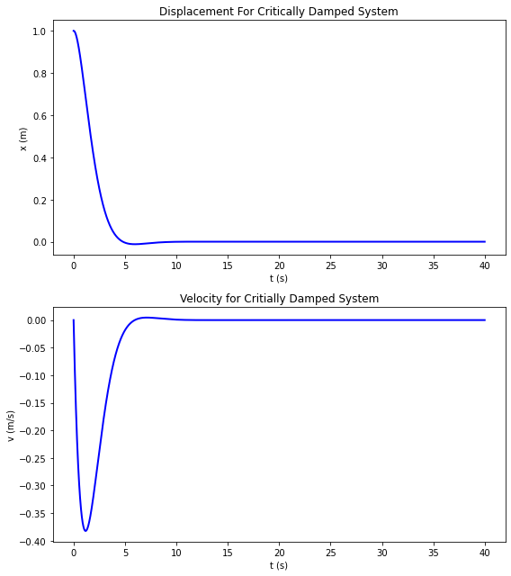

```python
%matplotlib inline
from math import *
import numpy as np
import matplotlib.pyplot as plt

#𝑥¨+2𝜁𝜔𝑛𝑥˙+𝜔2𝑛𝑥=𝐹(𝑡)𝑚
zeta = 1.
omega_n= 1.
#RK3 constants
c1 = 1./6
c2 = 2./6
c3 = 2./6
c4 = 1./6
a2 = 1./2
a3 = 1./2
a4 = 1.
b21 = 1./2
b31 = 0
b32 = 1./2
b41 = 0
b42 = 0
b43 = 0

F_over_m = lambda t: 0
f_x = lambda t,x,v: v                  #this is equation for dx/dt = v t= indep. x = prim. dep. v = dep
f_v = lambda t,x,v: F_over_m(t)-2*zeta*omega_n*v - (omega_n**2)*x    #this is equation for dv/dt = F_over_m(T)-2*gamma*v- k*x
# t = indep, prim. dep = v x is also dep.

def rk4_x(ti, xi, vi, dt):
    K1 = f_x(ti,xi,vi)
    K2 = f_x(ti+a2*dt,xi+b21*K1*dt,vi)
    K3 = f_x(ti+a3*dt,xi+b31*K1*dt+b32*K2*dt,vi)
    K4 = f_x(ti+a4*dt,xi+b41*K1*dt+b42*K2*dt+b43*K3*dt,vi)
    xip1 = xi+(c1*K1+c2*K2+c3*K3+c4*K4)*dt
    return xip1

def rk4_v(ti, xi, vi, dt):
    K1 = f_v(ti,xi,vi)
    K2 = f_v(ti+a2*dt,xi,vi+b21*K1*dt)
    K3 = f_v(ti+a3*dt,xi,vi+b31*K1*dt+b32*K2*dt)
    K4 = f_x(ti+a4*dt,xi,vi+b41*K1*dt+b42*K2*dt+b43*K3*dt)
    vip1 = vi+(c1*K1+c2*K2+c3*K3+c4*K4)*dt
    return vip1

ti = 0.0    #initial value for t
tf = 40    #final value for t
n = 4000 #number of segments
dt = (tf-ti)/n   #step size
t = np.zeros(n+1)
x = np.zeros(n+1)
v = np.zeros(n+1)
x_iv = 1.0 #m
v_iv = 0.0 #m/s
t[0] = ti      #initial condition
x[0] = x_iv
v[0] = v_iv

for i in range(1,n+1):
    t[i] = ti + i*dt
    x[i] = rk4_x(t[i-1],x[i-1],v[i-1],dt)
    v[i] = rk4_v(t[i-1],x[i-1],v[i-1],dt)


fig = plt.figure(figsize=(8,9))
ax1 = plt.subplot(211)
#plt.title("x versus t and v versus t")
plt.plot(t,x,label="x vs. t",color="b",linewidth="2.0")
plt.xlabel("t (s)")
plt.ylabel("x (m)")
plt.title("Displacement For Critically Damped System")

ax2 = plt.subplot(212,sharex=ax1)
plt.plot(t,v,label="v vs. t",color="b",linewidth="2.0")
plt.xlabel("t (s)")
plt.ylabel("v (m/s)")
plt.title("Velocity for Critially Damped System")

plt.tight_layout()
plt.show()
```

# Analysis for overdamped, underdamped and critically damped systems

##### Each of the three graphs above, overdamped, underdamped and critically damped all have external forces of 0. The zeta values and the omega_n values play a major role in determing what the graph will look like.

##### For the overdamped system has a zeta value of 10 and a omega_n value of 1, making the position of the graph over time move extremely slow and not even oscillating. The velocity of the system does not change much either, it is relatively constant over the period of 40 seconds on the graph.

##### While the under damped system had a zeta value of .2 and a omega_n value of 1, with the same external force of 0. The under damped graphs oscillated quite a lot over a small period of time and the velocity changed from a large negative number to 0 then to a slightly less large positive velocity, eventually going to 0.

##### And finally the critically damped graphs where zeta = 1 and omega_n also = 1. This graph looks similar to the overdamped, but the positions moved at a much faster rate down to zero. The velocity graph has a initial negative velocity and then approaches 0 over time.

# Changing the function f(t)/m to non-constant values

## 1st test case

#### where x(0) = 1 and v(0) = 0

#### $\large \zeta {}$ = .2

#### $\large {\omega}{}$ = 1 rad/s

##### In this example F(t)/m equals t, as you see from this equation earlier,

##### $\large \ddot x + 2 \zeta \omega_n \dot x + {\omega}_n^2 x = \frac{F(t)}{m}$

##### which means that there is an external force acting upon the system.

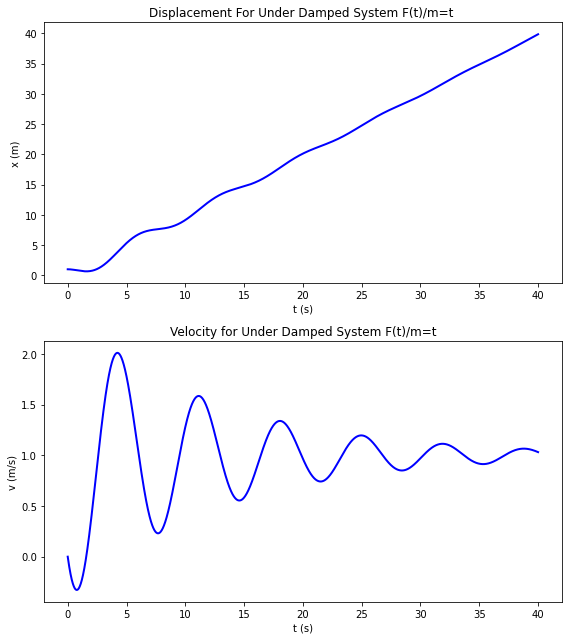

```python
%matplotlib inline
from math import *
import numpy as np
import matplotlib.pyplot as plt

#𝑥¨+2𝜁𝜔𝑛𝑥˙+𝜔2𝑛𝑥=𝐹(𝑡)𝑚
#This zeta is a ratio of C/C(critical), this is value will give us an under damped graph and system
zeta = .2
omega_n= 1
#RK4 constants for classical
c1 = 1./6
c2 = 2./6
c3 = 2./6
c4 = 1./6
a2 = 1./2
a3 = 1./2
a4 = 1.
b21 = 1./2
b31 = 0
b32 = 1./2
b41 = 0
b42 = 0
b43 = 0

#Creating our variables using lambda functions because they depend on the other variables like t,x and v.
#F_over_m is set to 0 because we are testing without an external force.
F_over_m = lambda t: t
f_x = lambda t,x,v: v                  #this is equation for dx/dt = v t= indep. x = prim. dep. v = dep
f_v = lambda t,x,v: F_over_m(t)-2*zeta*omega_n*v - (omega_n**2)*x    #this is equation for dv/dt = F_over_m(T)-2*gamma*v- k*x
# t = indep, prim. dep = v x is also dep.

#The Runge-Kutta 4th order
def rk4_x(ti, xi, vi, dt):
    K1 = f_x(ti,xi,vi)
    K2 = f_x(ti+a2*dt,xi+b21*K1*dt,vi)
    K3 = f_x(ti+a3*dt,xi+b31*K1*dt+b32*K2*dt,vi)
    K4 = f_x(ti+a4*dt,xi+b41*K1*dt+b42*K2*dt+b43*K3*dt,vi)
    xip1 = xi+(c1*K1+c2*K2+c3*K3+c4*K4)*dt
    return xip1

def rk4_v(ti, xi, vi, dt):
    K1 = f_v(ti,xi,vi)
    K2 = f_v(ti+a2*dt,xi,vi+b21*K1*dt)
    K3 = f_v(ti+a3*dt,xi,vi+b31*K1*dt+b32*K2*dt)
    K4 = f_x(ti+a4*dt,xi,vi+b41*K1*dt+b42*K2*dt+b43*K3*dt)
    vip1 = vi+(c1*K1+c2*K2+c3*K3+c4*K4)*dt
    return vip1

ti = 0.0    #initial value for t
tf = 40    #final value for t
n = 4000 #number of segments
dt = (tf-ti)/n   #step size
t = np.zeros(n+1)
x = np.zeros(n+1)
v = np.zeros(n+1)
x_iv = 1.0 #m
v_iv = 0.0 #m/s
t[0] = ti      #initial condition
x[0] = x_iv
v[0] = v_iv

for i in range(1,n+1):
    t[i] = ti + i*dt
    x[i] = rk4_x(t[i-1],x[i-1],v[i-1],dt)
    v[i] = rk4_v(t[i-1],x[i-1],v[i-1],dt)


fig = plt.figure(figsize=(8,9))
ax1 = plt.subplot(211)
#plt.title("x versus t and v versus t")
plt.plot(t,x,label="x vs. t",color="b",linewidth="2.0")
plt.xlabel("t (s)")
plt.ylabel("x (m)")
plt.title("Displacement For Under Damped System F(t)/m=t ")

ax2 = plt.subplot(212,sharex=ax1)
plt.plot(t,v,label="v vs. t",color="b",linewidth="2.0")
plt.xlabel("t (s)")
plt.ylabel("v (m/s)")
plt.title("Velocity for Under Damped System F(t)/m=t")

plt.tight_layout()
plt.show()
```

# Changing the function f(t)/m to non-constant values

## 2nd test case

#### where x(0) = 1 and v(0) = 0

#### $\large \zeta {}$ = .2

#### $\large {\omega}{}$ = 1 rad/s

##### In this example F(t)/m equals t^2, as you see from this equation earlier,

##### $\large \ddot x + 2 \zeta \omega_n \dot x + {\omega}_n^2 x = \frac{F(t)}{m}$

##### which means that there is an external force acting upon the system.

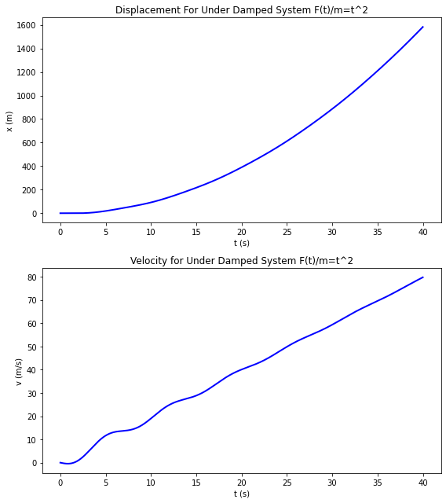

```python
%matplotlib inline
from math import *
import numpy as np
import matplotlib.pyplot as plt

#𝑥¨+2𝜁𝜔𝑛𝑥˙+𝜔2𝑛𝑥=𝐹(𝑡)𝑚
#This zeta is a ratio of C/C(critical), this is value will give us an under damped graph and system
zeta = .2
omega_n= 1
#RK4 constants for classical
c1 = 1./6
c2 = 2./6
c3 = 2./6
c4 = 1./6
a2 = 1./2
a3 = 1./2
a4 = 1.
b21 = 1./2
b31 = 0
b32 = 1./2
b41 = 0
b42 = 0
b43 = 0

#Creating our variables using lambda functions because they depend on the other variables like t,x and v.
#F_over_m is set to 0 because we are testing without an external force.
F_over_m = lambda t: t**2
f_x = lambda t,x,v: v                  #this is equation for dx/dt = v t= indep. x = prim. dep. v = dep
f_v = lambda t,x,v: F_over_m(t)-2*zeta*omega_n*v - (omega_n**2)*x    #this is equation for dv/dt = F_over_m(T)-2*gamma*v- k*x
# t = indep, prim. dep = v x is also dep.

#The Runge-Kutta 4th order
def rk4_x(ti, xi, vi, dt):
    K1 = f_x(ti,xi,vi)
    K2 = f_x(ti+a2*dt,xi+b21*K1*dt,vi)
    K3 = f_x(ti+a3*dt,xi+b31*K1*dt+b32*K2*dt,vi)
    K4 = f_x(ti+a4*dt,xi+b41*K1*dt+b42*K2*dt+b43*K3*dt,vi)
    xip1 = xi+(c1*K1+c2*K2+c3*K3+c4*K4)*dt
    return xip1

def rk4_v(ti, xi, vi, dt):
    K1 = f_v(ti,xi,vi)
    K2 = f_v(ti+a2*dt,xi,vi+b21*K1*dt)
    K3 = f_v(ti+a3*dt,xi,vi+b31*K1*dt+b32*K2*dt)
    K4 = f_x(ti+a4*dt,xi,vi+b41*K1*dt+b42*K2*dt+b43*K3*dt)
    vip1 = vi+(c1*K1+c2*K2+c3*K3+c4*K4)*dt
    return vip1

ti = 0.0    #initial value for t
tf = 40    #final value for t
n = 4000 #number of segments
dt = (tf-ti)/n   #step size
t = np.zeros(n+1)
x = np.zeros(n+1)
v = np.zeros(n+1)
x_iv = 1.0 #m
v_iv = 0.0 #m/s
t[0] = ti      #initial condition
x[0] = x_iv
v[0] = v_iv

for i in range(1,n+1):
    t[i] = ti + i*dt
    x[i] = rk4_x(t[i-1],x[i-1],v[i-1],dt)
    v[i] = rk4_v(t[i-1],x[i-1],v[i-1],dt)


fig = plt.figure(figsize=(8,9))
ax1 = plt.subplot(211)
#plt.title("x versus t and v versus t")
plt.plot(t,x,label="x vs. t",color="b",linewidth="2.0")
plt.xlabel("t (s)")
plt.ylabel("x (m)")
plt.title("Displacement For Under Damped System F(t)/m=t^2")

ax2 = plt.subplot(212,sharex=ax1)
plt.plot(t,v,label="v vs. t",color="b",linewidth="2.0")
plt.xlabel("t (s)")
plt.ylabel("v (m/s)")
plt.title("Velocity for Under Damped System F(t)/m=t^2")

plt.tight_layout()
plt.show()
```

# Changing the function f(t)/m to non-constant values

## 3rd test case

#### where x(0) = 1 and v(0) = 0

#### $\large \zeta {}$ = .2

#### $\large {\omega}{}$ = 1 rad/s

##### In this example F(t)/m equals 5, as you see from this equation earlier,

##### $\large \ddot x + 2 \zeta \omega_n \dot x + {\omega}_n^2 x = \frac{F(t)}{m}$

##### which means that there is an external force acting upon the system.

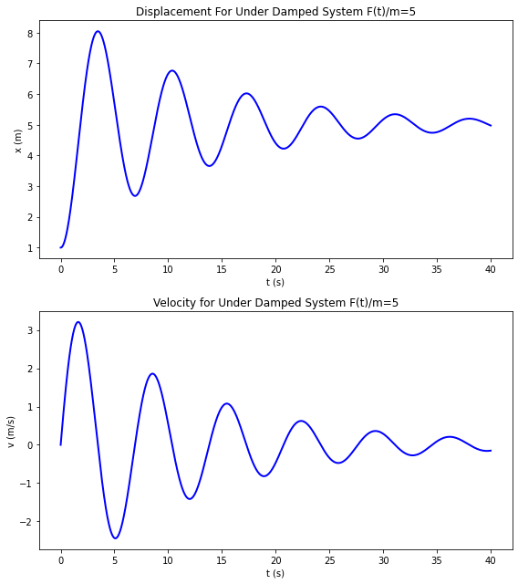

```python
%matplotlib inline
from math import *
import numpy as np
import matplotlib.pyplot as plt

#𝑥¨+2𝜁𝜔𝑛𝑥˙+𝜔2𝑛𝑥=𝐹(𝑡)𝑚
#This zeta is a ratio of C/C(critical), this is value will give us an under damped graph and system
zeta = .2
omega_n= 1
#RK4 constants for classical
c1 = 1./6
c2 = 2./6
c3 = 2./6
c4 = 1./6
a2 = 1./2
a3 = 1./2
a4 = 1.
b21 = 1./2
b31 = 0
b32 = 1./2
b41 = 0
b42 = 0
b43 = 0

#Creating our variables using lambda functions because they depend on the other variables like t,x and v.
#F_over_m is set to 0 because we are testing without an external force.
F_over_m = lambda t: 5
f_x = lambda t,x,v: v                  #this is equation for dx/dt = v t= indep. x = prim. dep. v = dep
f_v = lambda t,x,v: F_over_m(t)-2*zeta*omega_n*v - (omega_n**2)*x    #this is equation for dv/dt = F_over_m(T)-2*gamma*v- k*x
# t = indep, prim. dep = v x is also dep.

#The Runge-Kutta 4th order
def rk4_x(ti, xi, vi, dt):
    K1 = f_x(ti,xi,vi)
    K2 = f_x(ti+a2*dt,xi+b21*K1*dt,vi)
    K3 = f_x(ti+a3*dt,xi+b31*K1*dt+b32*K2*dt,vi)
    K4 = f_x(ti+a4*dt,xi+b41*K1*dt+b42*K2*dt+b43*K3*dt,vi)
    xip1 = xi+(c1*K1+c2*K2+c3*K3+c4*K4)*dt
    return xip1

def rk4_v(ti, xi, vi, dt):
    K1 = f_v(ti,xi,vi)
    K2 = f_v(ti+a2*dt,xi,vi+b21*K1*dt)
    K3 = f_v(ti+a3*dt,xi,vi+b31*K1*dt+b32*K2*dt)
    K4 = f_x(ti+a4*dt,xi,vi+b41*K1*dt+b42*K2*dt+b43*K3*dt)
    vip1 = vi+(c1*K1+c2*K2+c3*K3+c4*K4)*dt
    return vip1

ti = 0.0    #initial value for t
tf = 40    #final value for t
n = 4000 #number of segments
dt = (tf-ti)/n   #step size
t = np.zeros(n+1)
x = np.zeros(n+1)
v = np.zeros(n+1)
x_iv = 1.0 #m
v_iv = 0.0 #m/s
t[0] = ti      #initial condition
x[0] = x_iv
v[0] = v_iv

for i in range(1,n+1):
    t[i] = ti + i*dt
    x[i] = rk4_x(t[i-1],x[i-1],v[i-1],dt)
    v[i] = rk4_v(t[i-1],x[i-1],v[i-1],dt)


fig = plt.figure(figsize=(8,9))
ax1 = plt.subplot(211)
#plt.title("x versus t and v versus t")
plt.plot(t,x,label="x vs. t",color="b",linewidth="2.0")
plt.xlabel("t (s)")
plt.ylabel("x (m)")
plt.title("Displacement For Under Damped System F(t)/m=5")

ax2 = plt.subplot(212,sharex=ax1)
plt.plot(t,v,label="v vs. t",color="b",linewidth="2.0")
plt.xlabel("t (s)")
plt.ylabel("v (m/s)")
plt.title("Velocity for Under Damped System F(t)/m=5")

plt.tight_layout()
plt.show()
```

# Analysis of 3 different values of F(t)/m, which the first 2 test case values are non-constant and the third is a constant, using underdamped systems

##### The first test case used f(t)/m = t, which the position graph eventually straightened out to look like the graph y=x. While the velocity graph compared to the original underdamped graph looks relatively the same.

##### The second test case used f(t)/m = t^2 which the position graph eventually curved to look like the graph y=x^2. Then the velocity graph looks almost exactly like the position graph of the first test case, which makes sense, it is just taking the derivative of the second test case value for f(t)/m.

##### The third test case used f(t)/m = 5 which osciallted inversly, or opposite of the original underdamped system, but overall looks mainly the same.